# Exploratory Data Analysis

#### Author: Joaquin Menendez (jm622)

```python
# First we import the libraries that we are going to use
import numpy as np
import pandas as pd
import matplotlib.pyplot as plt
from scipy import stats
import seaborn as sns #A ploting library with more options
```

```python
#import data located in the '/data/Admission_Predict_Ver1.csv' folder
data = pd.read_csv('./data/Admission_Predict_Ver1.csv')
```

The dataset contains 500 inputs, where every row is an Indian student that applied to a master program at the USA. Every row has nine parameters which are considered for the admissions comitee of the graduate schools. The parameters included are : 1. GRE Scores ( out of 340 ) 2. TOEFL Scores ( out of 120 ) 3. University Rating ( out of 5 ) 4. Statement of Purpose and Letter of Recommendation Strength ( out of 5 ) 5. Undergraduate GPA ( out of 10 ) 6. Research Experience (either 0 or 1 ) 7. Chance of Admit (ranging from 0 to 1 ).

This dataset has a calculated parameter -> `Chance of admit`. This parameter has been calculated by the owner of the dataset. Unfortunately, the information regarding if the applicant was admitted or not is not accessible. Also, it seems that this dataset only takes one application per subject, when it's a known fact that rarely one applicant applies to only one master program. Additional data from individuals could be useful, despite usually universities do not ask for age and gender information, this data could be obtained looking the amount of years passed from graduating and the name of the applicant. This information could be useful data to add in the future.

```python
#We plot to see that everything is ok.
data.head(20)
```

|  | Serial No. | GRE Score | TOEFL Score | University Rating | SOP | LOR | CGPA | Research | Chance of Admit |
| --- | --- | --- | --- | --- | --- | --- | --- | --- | --- |
| 0 | 1 | 337 | 118 | 4 | 4.5 | 4.5 | 9.65 | 1 | 0.92 |
| 1 | 2 | 324 | 107 | 4 | 4.0 | 4.5 | 8.87 | 1 | 0.76 |
| 2 | 3 | 316 | 104 | 3 | 3.0 | 3.5 | 8.00 | 1 | 0.72 |
| 3 | 4 | 322 | 110 | 3 | 3.5 | 2.5 | 8.67 | 1 | 0.80 |
| 4 | 5 | 314 | 103 | 2 | 2.0 | 3.0 | 8.21 | 0 | 0.65 |
| 5 | 6 | 330 | 115 | 5 | 4.5 | 3.0 | 9.34 | 1 | 0.90 |
| 6 | 7 | 321 | 109 | 3 | 3.0 | 4.0 | 8.20 | 1 | 0.75 |
| 7 | 8 | 308 | 101 | 2 | 3.0 | 4.0 | 7.90 | 0 | 0.68 |
| 8 | 9 | 302 | 102 | 1 | 2.0 | 1.5 | 8.00 | 0 | 0.50 |
| 9 | 10 | 323 | 108 | 3 | 3.5 | 3.0 | 8.60 | 0 | 0.45 |
| 10 | 11 | 325 | 106 | 3 | 3.5 | 4.0 | 8.40 | 1 | 0.52 |
| 11 | 12 | 327 | 111 | 4 | 4.0 | 4.5 | 9.00 | 1 | 0.84 |
| 12 | 13 | 328 | 112 | 4 | 4.0 | 4.5 | 9.10 | 1 | 0.78 |
| 13 | 14 | 307 | 109 | 3 | 4.0 | 3.0 | 8.00 | 1 | 0.62 |
| 14 | 15 | 311 | 104 | 3 | 3.5 | 2.0 | 8.20 | 1 | 0.61 |
| 15 | 16 | 314 | 105 | 3 | 3.5 | 2.5 | 8.30 | 0 | 0.54 |
| 16 | 17 | 317 | 107 | 3 | 4.0 | 3.0 | 8.70 | 0 | 0.66 |
| 17 | 18 | 319 | 106 | 3 | 4.0 | 3.0 | 8.00 | 1 | 0.65 |
| 18 | 19 | 318 | 110 | 3 | 4.0 | 3.0 | 8.80 | 0 | 0.63 |
| 19 | 20 | 303 | 102 | 3 | 3.5 | 3.0 | 8.50 | 0 | 0.62 |

```python
# Let's check for any null value in the data set
data.isnull().sum()
```

```
Serial No.           0
GRE Score            0
TOEFL Score          0
University Rating    0
SOP                  0
LOR                  0
CGPA                 0
Research             0
Chance of Admit      0
dtype: int64
```

```python
# Lets Check for data type
data.info()
# Data seems to be clean, without missing values and well structured, everyhing parameter seems to be in an integer/float type.
```

```
<class 'pandas.core.frame.DataFrame'>
RangeIndex: 500 entries, 0 to 499
Data columns (total 9 columns):
Serial No.           500 non-null int64
GRE Score            500 non-null int64
TOEFL Score          500 non-null int64
University Rating    500 non-null int64
SOP                  500 non-null float64
LOR                  500 non-null float64
CGPA                 500 non-null float64
Research             500 non-null int64
Chance of Admit      500 non-null float64
dtypes: float64(4), int64(5)
memory usage: 35.2 KB
```

```python
#Let's see first some descriptive stats about the data
data.describe()
```

|  | Serial No. | GRE Score | TOEFL Score | University Rating | SOP | LOR | CGPA | Research | Chance of Admit |
| --- | --- | --- | --- | --- | --- | --- | --- | --- | --- |
| count | 500.000000 | 500.000000 | 500.000000 | 500.000000 | 500.000000 | 500.00000 | 500.000000 | 500.000000 | 500.00000 |
| mean | 250.500000 | 316.472000 | 107.192000 | 3.114000 | 3.374000 | 3.48400 | 8.576440 | 0.560000 | 0.72174 |
| std | 144.481833 | 11.295148 | 6.081868 | 1.143512 | 0.991004 | 0.92545 | 0.604813 | 0.496884 | 0.14114 |
| min | 1.000000 | 290.000000 | 92.000000 | 1.000000 | 1.000000 | 1.00000 | 6.800000 | 0.000000 | 0.34000 |
| 25% | 125.750000 | 308.000000 | 103.000000 | 2.000000 | 2.500000 | 3.00000 | 8.127500 | 0.000000 | 0.63000 |
| 50% | 250.500000 | 317.000000 | 107.000000 | 3.000000 | 3.500000 | 3.50000 | 8.560000 | 1.000000 | 0.72000 |
| 75% | 375.250000 | 325.000000 | 112.000000 | 4.000000 | 4.000000 | 4.00000 | 9.040000 | 1.000000 | 0.82000 |
| max | 500.000000 | 340.000000 | 120.000000 | 5.000000 | 5.000000 | 5.00000 | 9.920000 | 1.000000 | 0.97000 |

```
Text(0.5,1,'CGPA Histogram')
```

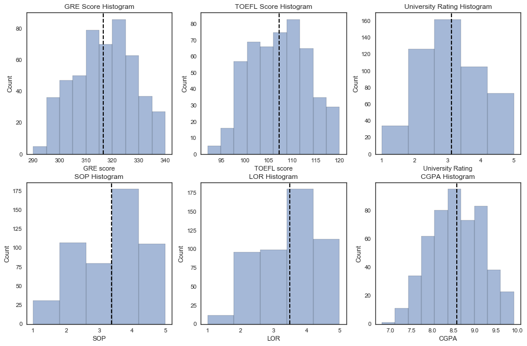

```python
#Let's plot some graphs to visually explore the data
plt.figure(figsize=(15,15))
plt.subplot(3,3,1)
plt.hist(data['GRE Score'], alpha=0.5, histtype='bar',ec='black') #Don't know the number of bins, so I would use the default option
plt.axvline(x= data['GRE Score'].mean(), linestyle = "--", color = "black",label= "Mean" )
plt.ylabel('Count')
plt.xlabel('GRE score')
plt.title('GRE Score Histogram')

plt.subplot(3,3,2)
plt.hist(data['TOEFL Score'], alpha=0.5, histtype='bar',ec='black') #Don't know the number of bins, so I would use the default option
plt.axvline(x= data['TOEFL Score'].mean(), linestyle = "--", color = "black",label= "Mean" )
plt.ylabel('Count')
plt.xlabel('TOEFL score')
plt.title('TOEFL Score Histogram')

plt.subplot(3,3,3)
plt.hist(data['University Rating'], bins= 5, alpha=0.5, histtype='bar',ec='black') #Ranking from 1 to 5, integers
plt.axvline(x= data['University Rating'].mean(), linestyle = "--", color = "black",label= "Mean" )
plt.ylabel('Count')
plt.xlabel('University Rating')
plt.title('University Rating Histogram')

plt.subplot(3,3,4)
plt.hist(data['SOP'], bins= 5, alpha=0.5, histtype='bar',ec='black') #Ranking from 1 to 5, integers
plt.axvline(x= data['SOP'].mean(), linestyle = "--", color = "black",label= "Mean" )
plt.ylabel('Count')
plt.xlabel('SOP')
plt.title('SOP Histogram')

plt.subplot(3,3,5)
plt.hist(data['LOR '], bins= 5, alpha=0.5, histtype='bar',ec='black') #Ranking from 1 to 5, integers
plt.axvline(x= data['LOR '].mean(), linestyle = "--", color = "black",label= "Mean" )
plt.ylabel('Count')
plt.xlabel('LOR')
plt.title('LOR Histogram')

plt.subplot(3,3,6)
plt.hist(data['CGPA'], bins= 10, alpha=0.5, histtype='bar',ec='black') #Indian GPA is from 1 to 10
plt.axvline(x= data['CGPA'].mean(), linestyle = "--", color = "black",label= "Mean" )
plt.ylabel('Count')
plt.xlabel('CGPA')
plt.title('CGPA Histogram')
```

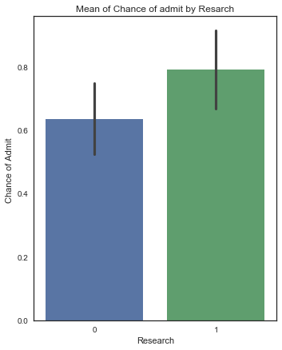

```python
from numpy import median,mean
plt.figure(figsize= (12,7))
plt.subplot(1,2,1)
plt.title('Mean of Chance of admit by Resarch')
sns.barplot(x='Research', y='Chance of Admit ', data = data , ci = 'sd')
```

```python
#Let's see if we could plot a correlation plot with all our variables
data.corr()
```

|  | Serial No. | GRE Score | TOEFL Score | University Rating | SOP | LOR | CGPA | Research | Chance of Admit |
| --- | --- | --- | --- | --- | --- | --- | --- | --- | --- |
| Serial No. | 1.000000 | -0.103839 | -0.141696 | -0.067641 | -0.137352 | -0.003694 | -0.074289 | -0.005332 | 0.008505 |
| GRE Score | -0.103839 | 1.000000 | 0.827200 | 0.635376 | 0.613498 | 0.524679 | 0.825878 | 0.563398 | 0.810351 |
| TOEFL Score | -0.141696 | 0.827200 | 1.000000 | 0.649799 | 0.644410 | 0.541563 | 0.810574 | 0.467012 | 0.792228 |
| University Rating | -0.067641 | 0.635376 | 0.649799 | 1.000000 | 0.728024 | 0.608651 | 0.705254 | 0.427047 | 0.690132 |
| SOP | -0.137352 | 0.613498 | 0.644410 | 0.728024 | 1.000000 | 0.663707 | 0.712154 | 0.408116 | 0.684137 |
| LOR | -0.003694 | 0.524679 | 0.541563 | 0.608651 | 0.663707 | 1.000000 | 0.637469 | 0.372526 | 0.645365 |
| CGPA | -0.074289 | 0.825878 | 0.810574 | 0.705254 | 0.712154 | 0.637469 | 1.000000 | 0.501311 | 0.882413 |
| Research | -0.005332 | 0.563398 | 0.467012 | 0.427047 | 0.408116 | 0.372526 | 0.501311 | 1.000000 | 0.545871 |
| Chance of Admit | 0.008505 | 0.810351 | 0.792228 | 0.690132 | 0.684137 | 0.645365 | 0.882413 | 0.545871 | 1.000000 |

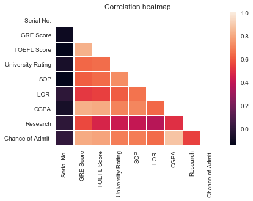

```python
#Let's make a triangular heatmap.
sns.set(style="white")

mask = np.zeros_like(data.corr(), dtype=np.bool)  #creates a matrix of zeros of the same size as the correlation matrix
mask[np.triu_indices_from(mask)] = True
plt.title('Correlation heatmap')
sns.heatmap(data.corr(), mask = mask, linewidths=.5)
```

```
Text(0.5,0.98,'Correlation between predictor CGPA and response')
```

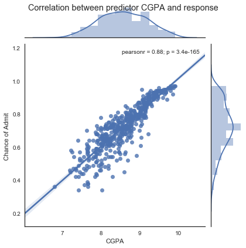

```python
# We observe that 'CGPA' is the variable that most correlate with 'Chance of Admit'. Let's look that in more detail.
g =sns.jointplot(x='CGPA', y='Chance of Admit ', data= data, kind="reg");
g.fig.suptitle('Correlation between predictor CGPA and response')
```

```
R2 = 0.656668
p = 0.000000
```

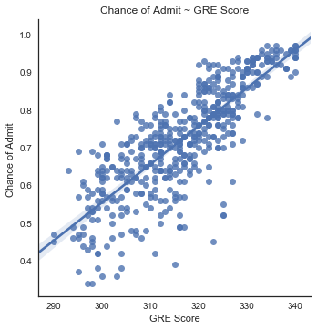

```python
#Lets analyze if the eigth first parameters have a linear relation with the parameter 'Chances of Admit'.
#In a ideal world, We would have the results of the applications. But given that this data set do not have this, we would use this variable as it was
#the dependent variable of our model

g = sns.lmplot(x='GRE Score', y='Chance of Admit ', data= data)
plt.title("Chance of Admit ~ GRE Score")
slope, intercept, r_value, p_value, std_err = stats.linregress(x=data['GRE Score'], y=data['Chance of Admit '])
pred_values = slope * data['GRE Score'] + intercept
residuals = data['Chance of Admit '] - pred_values
print ('R2 = %f \np = %f' % (r_value**2,p_value))
```

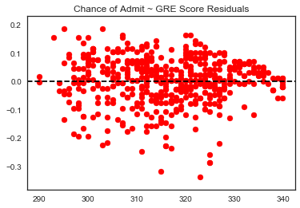

```python
plt.title('Chance of Admit ~ GRE Score Residuals')
plt.scatter(data['GRE Score'],residuals, color = 'red')
plt.axhline(y= 0, color = 'black' , linestyle = '--')
```

```
R2 = 0.627625
 p = 0.000000
```

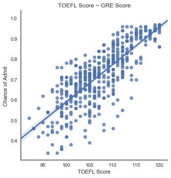

```python
g = sns.lmplot(x='TOEFL Score', y='Chance of Admit ', data= data)
plt.title("TOEFL Score ~ GRE Score")
slope, intercept, r_value, p_value, std_err = stats.linregress(x=data['TOEFL Score'], y=data['Chance of Admit '])
pred_values = slope * data['TOEFL Score'] + intercept
residuals = data['Chance of Admit '] - pred_values
print ('R2 = %f \n p = %f' % (r_value**2,p_value))
```

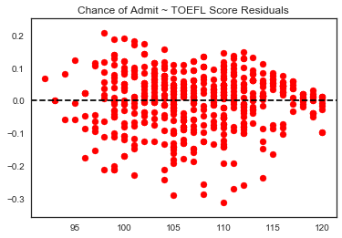

```python
plt.title('Chance of Admit ~ TOEFL Score Residuals')
plt.scatter(data['TOEFL Score'],residuals, color = 'red')
plt.axhline(y= 0, color = 'black' , linestyle = '--')
```

```
R2 = 0.476283
 p = 0.000000
```

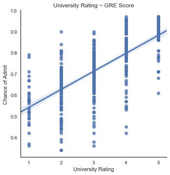

```python
g = sns.lmplot(x='University Rating', y='Chance of Admit ', data= data)
plt.title("University Rating ~ GRE Score")
slope, intercept, r_value, p_value, std_err = stats.linregress(x=data['University Rating'], y=data['Chance of Admit '])
print ('R2 = %f \n p = %f' % (r_value**2,p_value))
```

```
R2 = 0.468043
 p = 0.000000
```

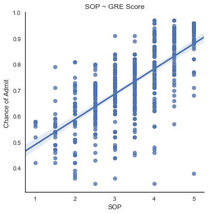

```python
g = sns.lmplot(x='SOP', y='Chance of Admit ', data= data)
plt.title("SOP ~ GRE Score")
slope, intercept, r_value, p_value, std_err = stats.linregress(x=data['SOP'], y=data['Chance of Admit '])
print ('R2 = %f \n p = %f' % (r_value**2,p_value))
```

```
R2 = 0.416495
 p = 0.000000
```

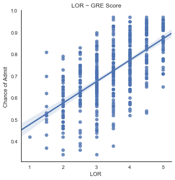

```python
g = sns.lmplot(x='LOR ', y='Chance of Admit ', data= data)
plt.title("LOR ~ GRE Score")
slope, intercept, r_value, p_value, std_err = stats.linregress(x=data['LOR '], y=data['Chance of Admit '])
print ('R2 = %f \n p = %f' % (r_value**2,p_value))
```

```
R2 = 0.778652
 p = 0.000000
```

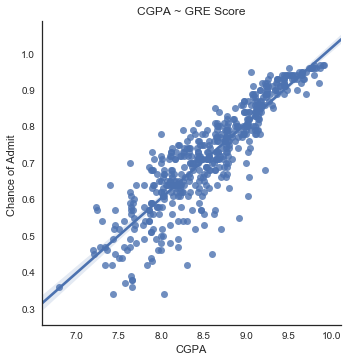

```python
g = sns.lmplot(x='CGPA', y='Chance of Admit ', data= data)
plt.title("CGPA ~ GRE Score")
slope, intercept, r_value, p_value, std_err = stats.linregress(x=data['CGPA'], y=data['Chance of Admit '])
print ('R2 = %f \n p = %f' % (r_value**2,p_value))
pred_values = slope * data['CGPA'] + intercept
residuals = data['Chance of Admit '] - pred_values
```

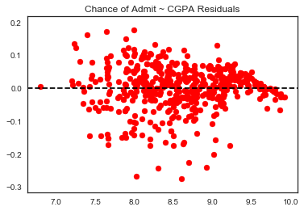

```python
plt.title('Chance of Admit ~ CGPA Residuals')
plt.scatter(data['CGPA'],residuals, color = 'red')
plt.axhline(y= 0, color = 'black' , linestyle = '--')
```

We made some linear regression to see the relation among the predictors and the outcome variable. We can visualize again that our predictors are useful to predict the outcome (ps < 0.001). Almost all predictor seem to have a linear relationship with exception of CGPA and TOEFL, they look that they could benefit from a quadratic transformation, and GRE looks something similar to a logarithmic distribution. Once again, we could observe that CGPA is the most useful predictor.

I have the hypothesis that a research background does not strongly correlates with the other variables, but it has an interaction effect with some of the predictors. To evaluate this, we are going to plot a linear model for every predictor variable differentiated by the research background.

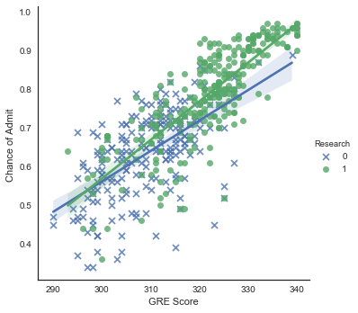

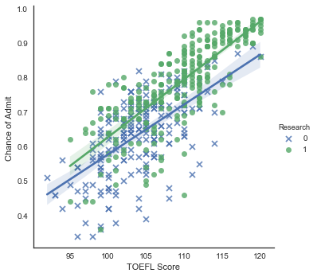

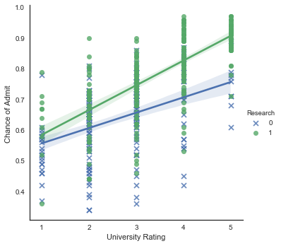

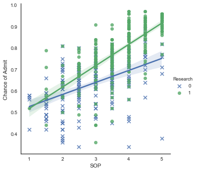

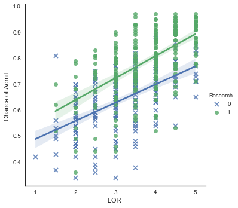

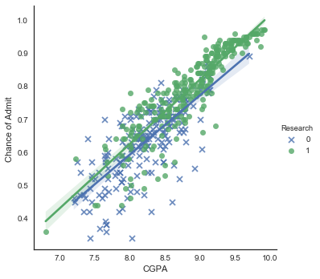

```python
g = sns.lmplot(x='GRE Score', y='Chance of Admit ', hue= 'Research' , truncate = True, markers=['x', 'o'],data= data)
g = sns.lmplot(x='TOEFL Score', y='Chance of Admit ', hue= 'Research' , truncate = True, markers=['x', 'o'],data= data)
g = sns.lmplot(x='University Rating', y='Chance of Admit ', hue= 'Research' , truncate = True, markers=['x', 'o'],data= data)
g = sns.lmplot(x='SOP', y='Chance of Admit ', hue= 'Research' , truncate = True, markers=['x', 'o'],data= data)
g = sns.lmplot(x='LOR ', y='Chance of Admit ', hue= 'Research' , truncate = True, markers=['x', 'o'],data= data)
g = sns.lmplot(x='CGPA', y='Chance of Admit ', hue= 'Research' , truncate = True, markers=['x', 'o'],data= data)
```

```python
#plt.figure(figsize=(10,10))
#sns.violinplot(x = 'University Rating', y='Chance of Admit ', hue= 'Research', split= 'True', inner= 'quart',data=data)
#sns.despine(offset=10, trim=True)
```

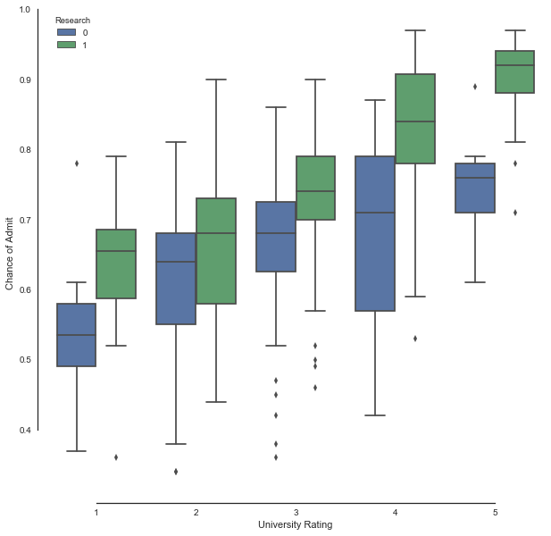

```python
plt.figure(figsize=(10,10))
sns.boxplot(x = 'University Rating', y='Chance of Admit ', hue= 'Research',data=data)
sns.despine(offset=10, trim=True)
```

We can observe that TOP Universities (1) tend to prioritize research background when they admit students. Interestingly, universities with the lowest rating also seem to give more importance to research background. This difference between research background is not so strong for middle rating universities.

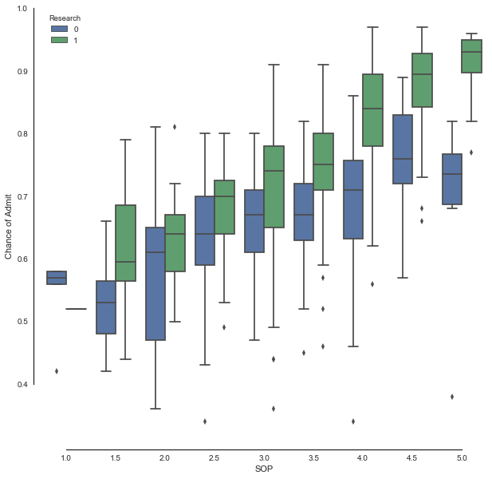

```python
plt.figure(figsize=(10,10))
sns.boxplot(x = 'SOP', y='Chance of Admit ', hue= 'Research',data=data)
sns.despine(offset=10, trim=True)
```

The motivation for choosing this dataset is that I have applied to two different internships that are education oriented. This data set seems to be a little naive, but I think the variables that I should end working are going to be like this. As summary, for Indian engineering students that are applying to a master program in the USA the best advice would be to have a prior experience in a research lab and try to reflect this experience in their SOP and ask to the members of the lab to write their LOR.